# Predicting İmdb Scores of Tv Shows and Movies in Netflix

Ahmet Göktuğ Özdemir

Capstone Project

December 2022

- Summary
- Motivation
- Literature Review
- Data Exploration & Codes
- Results
- Referances

# Summary

This project aims to make a algorithm that can predict a tv show or movies imdb score and if entry will get higher score than median score.The Internet Movie Database (IMDb) is an online database containing information and statistics about movies, TV shows and video games as well as actors, directors and other film industry professionals. İn this project dataset(1) was used which has all movies and tv shows from Netflix up to year 2021. Netflix is one of the most popular media and video streaming platforms. They have over 8000 movies or tv shows available on their platform, currently they have over 200M Subscribers globally. Dataset consist of 8807 rows and 12 columns. Project consist of data exploration, dataset preparation, making the algorithm and discussing results. At the moment it uses k-nn algorithm.

# Motivation

Currently Netflix is the biggest streaming service. I wanted to make something that could predict if something is worth my time. I used imdb rating as imdb scores are more reliable indicator of quality than Netflix's own scores. As for the reason I used only Netflix entrys I thought as Netflix is biggest streaming service their catalouge should be better than what is avaible in avarage and should be more known. With this I could know if something is good before it is released. I plan to use it for newly released titles rather than unreleased ones. This way before ratings are made I could decide if I should watch it or not.

# Literature Review

One of the widely used classification algorithms is k-Nearest Neighbours (k-NN). Its popularity is mainly due to its simplicity, effectiveness, ease of implementation and ability to add new data in the training set at any time. However, one of its main drawbacks is the fact that its performance is highly dependent on the proper selection of parameter k, i.e. the number of nearest neighbours that the algorithm examines. The most frequently used technique for the “best” k determination is the cross validation as there is no general rule for choosing the k value due to its dependency on the training dataset. However, selecting a fixed k value throughout the dataset does not take into account its special features, like data distribution, class separation, imbalanced classes, sparse and dense neighborhoods and noisy subspaces(2)

As other researches indicates Netflix data set provides very little data for each movie -- only its title, the ratings from the users and the date of the ratings -- so we use the Internet Movie Database for richer metadata. We also experimented with clustering sparser metadata like actors and actresses. We then ran experiments on predicting ratings with and without the richer metadata. We found that enriching that enriching our baseline collaborative filtering approach with movie metadata only made a small improvement of 0.1% in the root mean squared error (RMSE) of our predictions(3)

# Data Exploration & Codes

```python
!pip install git+https://github.com/nielth/cinemagoer
```

```
  Cloning https://github.com/nielth/cinemagoer to /tmp/pip-req-build-g76nbxtu
  Running command git clone -q https://github.com/nielth/cinemagoer /tmp/pip-req-build-g76nbxtu
```

We import our packages.

```python
import http.client
import imdb
import pandas as pd
import numpy as np
import matplotlib.pyplot as plt
from imdb import Cinemagoer
from sklearn.compose import make_column_transformer
from sklearn.preprocessing import OneHotEncoder
from sklearn.model_selection import train_test_split
from sklearn.feature_extraction.text import CountVectorizer
import seaborn as sb
import nltk as nl
from sklearn.neighbors import KNeighborsRegressor
from sklearn.model_selection import GridSearchCV
from sklearn.metrics import confusion_matrix
from sklearn.metrics import classification_report
from sklearn.model_selection import cross_val_score
from sklearn.preprocessing import MinMaxScaler
from sklearn.metrics import accuracy_score
from sklearn import preprocessing
from sklearn.neighbors import KNeighborsClassifier
from sklearn.metrics import accuracy_score, plot_confusion_matrix
```

```python
def remove_suffix(input_string, suffix):
    if suffix and input_string.endswith(suffix):
        return input_string[:-len(suffix)]
    return input_string
```

Because getting data from imdb api takes too much time I worked with only 100 data for this time. For gettin all data from imdb takes up to 15 hours. By changing nrows we can use more of dataset.

```python
pd.options.mode.chained_assignment=None

ia = Cinemagoer()

pd.set_option('display.max_rows', 1000)
pd.set_option('display.max_columns', 1000)
pd.set_option('display.width', 1000)

df = pd.read_csv("netflix_titles.csv",nrows=100)
print(df.head())

nullcheck=df.isnull()
```

```
  show_id     type                  title         director                                               cast        country          date_added  release_year rating   duration                                          listed_in                                        description
0      s1    Movie   Dick Johnson Is Dead  Kirsten Johnson                                                NaN  United States  September 25, 2021          2020  PG-13     90 min                                      Documentaries  As her father nears the end of his life, filmm...
1      s2  TV Show          Blood & Water              NaN  Ama Qamata, Khosi Ngema, Gail Mabalane, Thaban...   South Africa  September 24, 2021          2021  TV-MA  2 Seasons    International TV Shows, TV Dramas, TV Mysteries  After crossing paths at a party, a Cape Town t...
2      s3  TV Show              Ganglands  Julien Leclercq  Sami Bouajila, Tracy Gotoas, Samuel Jouy, Nabi...            NaN  September 24, 2021          2021  TV-MA   1 Season  Crime TV Shows, International TV Shows, TV Act...  To protect his family from a powerful drug lor...
3      s4  TV Show  Jailbirds New Orleans              NaN                                                NaN            NaN  September 24, 2021          2021  TV-MA   1 Season                             Docuseries, Reality TV  Feuds, flirtations and toilet talk go down amo...
4      s5  TV Show           Kota Factory              NaN  Mayur More, Jitendra Kumar, Ranjan Raj, Alam K...          India  September 24, 2021          2021  TV-MA  2 Seasons  International TV Shows, Romantic TV Shows, TV ...  In a city of coaching centers known to train I...
```

Showing null entry numbers.

```
show_id          0
type             0
title            0
director        38
cast            11
country         40
date_added       0
release_year     0
rating           0
duration         0
listed_in        0
description      0
dtype: int64
```

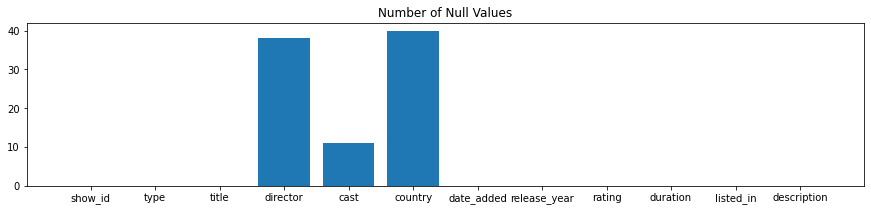

```python
print(df.isna().sum())

y=df.isna().sum()
x =df.columns
f = plt.figure()
f.set_figwidth(15)
f.set_figheight(3)
print()
plt.bar(x,y)
plt.title('Number of Null Values')
plt.show()
```

Getting missing values from imdb with cinemagoer api from imdb.

```python
for i in range(len((nullcheck["director"]))):
    if (((nullcheck["director"][i])==True)):
        try:
            movies = ia.search_movie(df["title"][i])
            if (len(movies)>0):
                movieid = movies[0].movieID
                truemovie = ia.get_movie(movieid)
                director = []
                print(i)
                for j in range(len(truemovie["directors"])):
                    director.append(truemovie["directors"][j]["name"])
            else:
                print("Film does not exist in imdb")
        except KeyError:
                    print("No director entry in imdb")
                    if(df["type"][i]=="TV Show"):
                        print("It is a Tv Show")
                        director.append("Tv Show")
        except imdb._exceptions.IMDbParserError:
                    print("Invalid title")
        except imdb._exceptions.IMDbDataAccessError:
                    print("Timed out")
                    i = i - 1
        except http.client.IncompleteRead:
                    print("Incomplete Read")
                    i = i - 1
        s = ','.join(director)
        df.iloc[:, 3][i] = s
```

```
1
No director entry in imdb
It is a Tv Show
3
No director entry in imdb
It is a Tv Show
4
No director entry in imdb
It is a Tv Show
10
No director entry in imdb
It is a Tv Show
14
No director entry in imdb
It is a Tv Show
15
No director entry in imdb
It is a Tv Show
17
No director entry in imdb
It is a Tv Show
19
No director entry in imdb
It is a Tv Show
21
No director entry in imdb
It is a Tv Show
25
No director entry in imdb
It is a Tv Show
31
No director entry in imdb
It is a Tv Show
32
No director entry in imdb
It is a Tv Show
33
No director entry in imdb
It is a Tv Show
Film does not exist in imdb
```

[output cut: 49 more lines]

```
No director entry in imdb
It is a Tv Show
92
No director entry in imdb
It is a Tv Show
95
97
No director entry in imdb
It is a Tv Show
98
No director entry in imdb
It is a Tv Show
99
No director entry in imdb
It is a Tv Show
```

```python
for i in range(len((nullcheck["country"]))):
    if (((nullcheck["country"][i])==True)):
        try:
            movies = ia.search_movie(df["title"][i])
            if (len(movies)>0):
                movieid = movies[0].movieID
                truemovie = ia.get_movie(movieid)
                country = []
                print(i)
                for j in range(len(truemovie["countries"])):
                    country.append(truemovie["countries"][j])
            else:
                print("Film does not exist in imdb")
            s = ','.join(country)
            df.iloc[:, 5][i] = s
        except KeyError:
                    print("No country entry in imdb")
        except imdb._exceptions.IMDbParserError:
                    print("Invalid title")
        except imdb._exceptions.IMDbDataAccessError:
                    print("Timed out")
                    i = i - 1
        except http.client.IncompleteRead:
                    print("Incomplete Read")
                    i = i - 1
```

```
2
3
5
6
10
11
13
14
16
18
19
20
22
23
26
30
31
33
Film does not exist in imdb
35
36
45
47
64
68
70
71
74
75
Film does not exist in imdb
78
79
80
83
85
86
87
88
89
No country entry in imdb
93
```

```python
df.to_csv('complete_netflix_data.csv')
for i in range(len(df["cast"])):
    try:
        if (nullcheck["cast"][i])==True:
            movies = ia.search_movie(df["title"][i])
            if (len(movies)>0):
                movieid = movies[0].movieID
                truemovie = ia.get_movie(movieid)
                cast=[]
                print(i)
                for j in range(len(truemovie["cast"])):
                    cast.append(truemovie["cast"][j]["name"])
            else:
                print("Film does not exist in imdb")
            s = ','.join(cast)
            df.iloc[:, 4][i] = s
    except KeyError:
                print("No cast entry in imdb")
    except imdb._exceptions.IMDbParserError:
            print("Invalid title")
    except imdb._exceptions.IMDbDataAccessError:
            print("Timed out")
            i = i - 1
    except http.client.IncompleteRead:
            print("Incompleted Read")
            i = i - 1
df.to_csv('complete_netflix_data.csv')
```

```
0
3
No cast entry in imdb
10
14
16
20
45
66
69
74
91
```

```python
score = []
for i in range(len((df["director"]))):
        try:
            movies = ia.search_movie(df["title"][i])
            if (len(movies)>0):
                movieid = movies[0].movieID
                truemovie = ia.get_movie(movieid)
                print(i)
                score.append(truemovie["rating"])
            else:
                print("Film does not exist in imdb")
                score.append(None)
        except KeyError:
                    print("No rating entry in imdb")
                    score.append(None)
        except imdb._exceptions.IMDbParserError:
                    print("Invalid title")
        except imdb._exceptions.IMDbDataAccessError:
                    print("Timed out")
                    i = i - 1
        except http.client.IncompleteRead:
                    print("Incomplete Read")
                    i = i - 1


df["Score"] = score
```

[output not shown]

[output cut: 45 more lines]

```
85
86
87
88
89
90
91
92
93
94
95
96
97
98
99
```

Showing remaining null values and dropping ones that could not be filled.

```python
print("Null entry number:")
print(df.isna().sum())
print()
print("Drop null entrys")
df.dropna(inplace=True)
```

```
Null entry number:
show_id         0
type            0
title           0
director        0
cast            1
country         1
date_added      0
release_year    0
rating          0
duration        0
listed_in       0
description     0
Score           2
dtype: int64

Drop null entrys
```

```python
df.to_csv('complete_netflix_data.csv')

print(df.head())
print()
print()
print("Null entry number:")
print(df.isna().sum())
print()
```

```
  show_id     type                 title         director                                               cast        country          date_added  release_year rating   duration                                          listed_in                                        description  Score
0      s1    Movie  Dick Johnson Is Dead  Kirsten Johnson  Michael Hilow,Ana Hoffman,Dick Johnson,Kirsten...  United States  September 25, 2021          2020  PG-13     90 min                                      Documentaries  As her father nears the end of his life, filmm...    7.4
1      s2  TV Show         Blood & Water          Tv Show  Ama Qamata, Khosi Ngema, Gail Mabalane, Thaban...   South Africa  September 24, 2021          2021  TV-MA  2 Seasons    International TV Shows, TV Dramas, TV Mysteries  After crossing paths at a party, a Cape Town t...    6.7
2      s3  TV Show             Ganglands  Julien Leclercq  Sami Bouajila, Tracy Gotoas, Samuel Jouy, Nabi...         France  September 24, 2021          2021  TV-MA   1 Season  Crime TV Shows, International TV Shows, TV Act...  To protect his family from a powerful drug lor...    7.0
4      s5  TV Show          Kota Factory          Tv Show  Mayur More, Jitendra Kumar, Ranjan Raj, Alam K...          India  September 24, 2021          2021  TV-MA  2 Seasons  International TV Shows, Romantic TV Shows, TV ...  In a city of coaching centers known to train I...    9.1
5      s6  TV Show         Midnight Mass    Mike Flanagan  Kate Siegel, Zach Gilford, Hamish Linklater, H...  United States  September 24, 2021          2021  TV-MA   1 Season                 TV Dramas, TV Horror, TV Mysteries  The arrival of a charismatic young priest brin...    7.7


Null entry number:
show_id         0
type            0
title           0
director        0
cast            0
country         0
date_added      0
release_year    0
rating          0
duration        0
listed_in       0
description     0
Score           0
dtype: int64
```

Showing column types.

```python
print(df.info())
```

```
<class 'pandas.core.frame.DataFrame'>
Int64Index: 96 entries, 0 to 99
Data columns (total 13 columns):
 #   Column        Non-Null Count  Dtype
---  ------        --------------  -----
 0   show_id       96 non-null     object
 1   type          96 non-null     object
 2   title         96 non-null     object
 3   director      96 non-null     object
 4   cast          96 non-null     object
 5   country       96 non-null     object
 6   date_added    96 non-null     object
 7   release_year  96 non-null     int64
 8   rating        96 non-null     object
 9   duration      96 non-null     object
 10  listed_in     96 non-null     object
 11  description   96 non-null     object
 12  Score         96 non-null     float64
dtypes: float64(1), int64(1), object(11)
memory usage: 10.5+ KB
None
```

```python
print(df.describe())
```

```
       release_year      Score
count     96.000000  96.000000
mean    2014.916667   6.644792
std       10.327956   1.153381
min     1975.000000   3.000000
25%     2012.750000   5.800000
50%     2021.000000   6.700000
75%     2021.000000   7.400000
max     2021.000000   9.100000
```

[figure not shown]

```python
y=df.isna().sum()
print()
x =df.columns
f = plt.figure()
f.set_figwidth(15)
f.set_figheight(3)
plt.bar(x,y)
plt.title('Number of Nan Values')
plt.show()
print()
print()
```

As we can see Netflix has more movies than Tv shows.

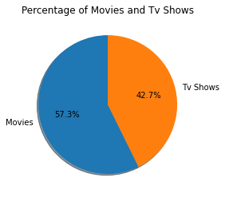

```python
graph = [df['type'].value_counts()['Movie'], df['type'].value_counts()['TV Show']]
label = ["Movies", "Tv Shows"]
y = graph
plt.pie(y, labels=label,autopct='%1.1f%%',shadow=True, startangle=90)
plt.title('Percentage of Movies and Tv Shows')
plt.show()
print()
print()
```

As seen in graphic united states has the most entrys.

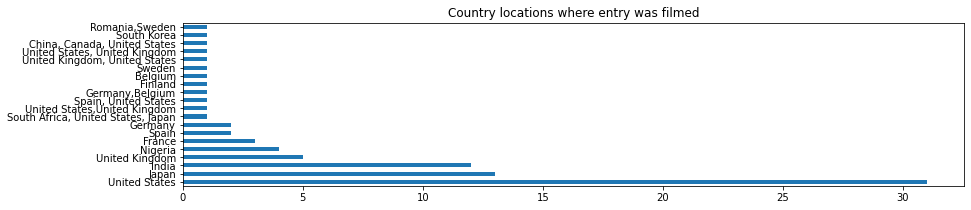

```python
f = plt.figure()
f.set_figwidth(14)
f.set_figheight(3)
df['country'].value_counts()[:20].plot(kind='barh')
plt.title('Country locations where entry was filmed')
plt.show()
```

Because Tv shows have no director entry in imdb I gave Tv show directors 'Tv Show' label. Because of this there seems to be a lot of tv shows in directors. After that we can see directors with most number of films.

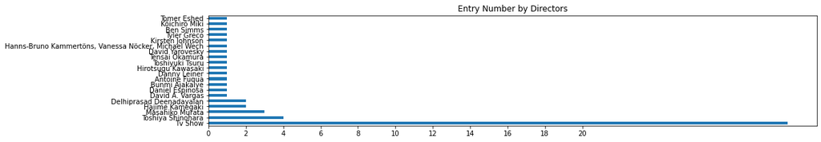

```python
f = plt.figure()
df['director'].value_counts()[:20].plot(kind='barh')
f.set_figwidth(16)
f.set_figheight(3)
interval = range(0, 22, 2)
plt.xticks(interval)
plt.title('Entry Number by Directors')
plt.show()
```

Below is some histograms of different values.

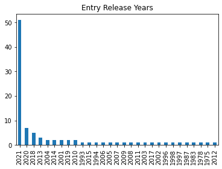

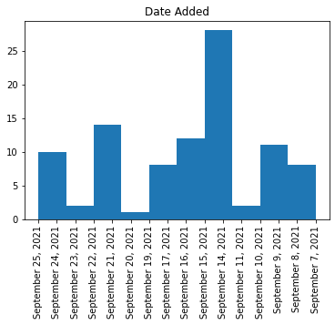

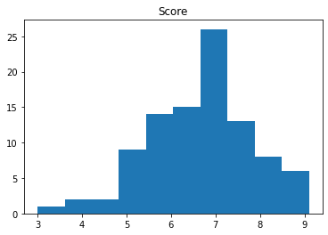

```python
graph = df['release_year'].value_counts().plot.bar()
plt.title('Entry Release Years')
plt.show()


print()
print()

plt.hist(df["date_added"])
plt.xticks(rotation = 90)
plt.title('Date Added')
plt.show()

print()
print()

plt.hist(df["Score"])
plt.title('Score')
plt.show()

print()
print()
```

We can see the scores median and means.

```python
print("Median Score")
print(df["Score"].median())
print("Mean Score")
print(df["Score"].agg('mean'))




df['director']=df['director'].astype('category')
df['country']=df['country'].astype('category')
df['cast']=df['cast'].astype('category')
df['listed_in']=df['listed_in'].astype('category')

df['type']=df['type'].astype('category')
df['rating']=df['rating'].astype('category')
df['release_year']=df['release_year'].astype('category')
```

```
Median Score
6.7
Mean Score
6.644791666666666
```

We use dummies to one hot encode our catagories. Reason we use dummies and not sklearn is we have multiple values in one cell.

```python
df1 = df['listed_in'].str.get_dummies(',').add_prefix('listed_in_')
df2 = df['country'].str.get_dummies(',').add_prefix('country_')
df3 = df['cast'].str.get_dummies(',').add_prefix('cast_')
df4 = df['director'].str.get_dummies(',').add_prefix('director_')

df=df.drop(['cast','director','listed_in','country'], axis=1)
df = pd.concat([df, df1,df2,df3,df4], axis=1, join='inner')
df
```

|  | show_id | type | title | date_added | release_year | rating | duration | description | Score | listed_in_ Anime Features | listed_in_ Classic Movies | listed_in_ Comedies | listed_in_ Crime TV Shows | listed_in_ Docuseries | listed_in_ Dramas | listed_in_ Horror Movies | listed_in_ Independent Movies | listed_in_ International Movies | listed_in_ International TV Shows | listed_in_ Kids' TV | listed_in_ Korean TV Shows | listed_in_ Music & Musicals | listed_in_ Reality TV | listed_in_ Romantic Movies | listed_in_ Romantic TV Shows | listed_in_ Sci-Fi & Fantasy | listed_in_ Spanish-Language TV Shows | listed_in_ Sports Movies | listed_in_ TV Action & Adventure | … |
| --- | --- | --- | --- | --- | --- | --- | --- | --- | --- | --- | --- | --- | --- | --- | --- | --- | --- | --- | --- | --- | --- | --- | --- | --- | --- | --- | --- | --- | --- | --- |
| 0 | s1 | Movie | Dick Johnson Is Dead | September 25, 2021 | 2020 | PG-13 | 90 min | As her father nears the end of his life, filmm... | 7.4 | 0 | 0 | 0 | 0 | 0 | 0 | 0 | 0 | 0 | 0 | 0 | 0 | 0 | 0 | 0 | 0 | 0 | 0 | 0 | 0 | … |
| 1 | s2 | TV Show | Blood & Water | September 24, 2021 | 2021 | TV-MA | 2 Seasons | After crossing paths at a party, a Cape Town t... | 6.7 | 0 | 0 | 0 | 0 | 0 | 0 | 0 | 0 | 0 | 0 | 0 | 0 | 0 | 0 | 0 | 0 | 0 | 0 | 0 | 0 | … |
| 2 | s3 | TV Show | Ganglands | September 24, 2021 | 2021 | TV-MA | 1 Season | To protect his family from a powerful drug lor... | 7.0 | 0 | 0 | 0 | 0 | 0 | 0 | 0 | 0 | 0 | 1 | 0 | 0 | 0 | 0 | 0 | 0 | 0 | 0 | 0 | 1 | … |
| 4 | s5 | TV Show | Kota Factory | September 24, 2021 | 2021 | TV-MA | 2 Seasons | In a city of coaching centers known to train I... | 9.1 | 0 | 0 | 0 | 0 | 0 | 0 | 0 | 0 | 0 | 0 | 0 | 0 | 0 | 0 | 0 | 1 | 0 | 0 | 0 | 0 | … |
| 5 | s6 | TV Show | Midnight Mass | September 24, 2021 | 2021 | TV-MA | 1 Season | The arrival of a charismatic young priest brin... | 7.7 | 0 | 0 | 0 | 0 | 0 | 0 | 0 | 0 | 0 | 0 | 0 | 0 | 0 | 0 | 0 | 0 | 0 | 0 | 0 | 0 | … |
| 6 | s7 | Movie | My Little Pony: A New Generation | September 24, 2021 | 2021 | PG | 91 min | Equestria's divided. But a bright-eyed hero be... | 6.8 | 0 | 0 | 0 | 0 | 0 | 0 | 0 | 0 | 0 | 0 | 0 | 0 | 0 | 0 | 0 | 0 | 0 | 0 | 0 | 0 | … |
| 7 | s8 | Movie | Sankofa | September 24, 2021 | 1993 | TV-MA | 125 min | On a photo shoot in Ghana, an American model s... | 7.0 | 0 | 0 | 0 | 0 | 0 | 0 | 0 | 1 | 1 | 0 | 0 | 0 | 0 | 0 | 0 | 0 | 0 | 0 | 0 | 0 | … |
| 8 | s9 | TV Show | The Great British Baking Show | September 24, 2021 | 2021 | TV-14 | 9 Seasons | A talented batch of amateur bakers face off in... | 8.6 | 0 | 0 | 0 | 0 | 0 | 0 | 0 | 0 | 0 | 0 | 0 | 0 | 0 | 1 | 0 | 0 | 0 | 0 | 0 | 0 | … |
| 9 | s10 | Movie | The Starling | September 24, 2021 | 2021 | PG-13 | 104 min | A woman adjusting to life after a loss contend... | 6.3 | 0 | 0 | 0 | 0 | 0 | 1 | 0 | 0 | 0 | 0 | 0 | 0 | 0 | 0 | 0 | 0 | 0 | 0 | 0 | 0 | … |
| 10 | s11 | TV Show | Vendetta: Truth, Lies and The Mafia | September 24, 2021 | 2021 | TV-MA | 1 Season | Sicily boasts a bold "Anti-Mafia" coalition. B... | 6.8 | 0 | 0 | 0 | 0 | 1 | 0 | 0 | 0 | 0 | 1 | 0 | 0 | 0 | 0 | 0 | 0 | 0 | 0 | 0 | 0 | … |
| 11 | s12 | TV Show | Bangkok Breaking | September 23, 2021 | 2021 | TV-MA | 1 Season | Struggling to earn a living in Bangkok, a man ... | 5.8 | 0 | 0 | 0 | 0 | 0 | 0 | 0 | 0 | 0 | 1 | 0 | 0 | 0 | 0 | 0 | 0 | 0 | 0 | 0 | 1 | … |
| 12 | s13 | Movie | Je Suis Karl | September 23, 2021 | 2021 | TV-MA | 127 min | After most of her family is murdered in a terr... | 5.5 | 0 | 0 | 0 | 0 | 0 | 0 | 0 | 0 | 1 | 0 | 0 | 0 | 0 | 0 | 0 | 0 | 0 | 0 | 0 | 0 | … |
| 13 | s14 | Movie | Confessions of an Invisible Girl | September 22, 2021 | 2021 | TV-PG | 91 min | When the clever but socially-awkward Tetê join... | 5.2 | 0 | 0 | 1 | 0 | 0 | 0 | 0 | 0 | 0 | 0 | 0 | 0 | 0 | 0 | 0 | 0 | 0 | 0 | 0 | 0 | … |
| 14 | s15 | TV Show | Crime Stories: India Detectives | September 22, 2021 | 2021 | TV-MA | 1 Season | Cameras following Bengaluru police on the job ... | 7.1 | 0 | 0 | 0 | 1 | 1 | 0 | 0 | 0 | 0 | 0 | 0 | 0 | 0 | 0 | 0 | 0 | 0 | 0 | 0 | 0 | … |
| 15 | s16 | TV Show | Dear White People | September 22, 2021 | 2021 | TV-MA | 4 Seasons | Students of color navigate the daily slights a... | 6.3 | 0 | 0 | 0 | 0 | 0 | 0 | 0 | 0 | 0 | 0 | 0 | 0 | 0 | 0 | 0 | 0 | 0 | 0 | 0 | 0 | … |
| 16 | s17 | Movie | Europe's Most Dangerous Man: Otto Skorzeny in ... | September 22, 2021 | 2020 | TV-MA | 67 min | Declassified documents reveal the post-WWII li... | 6.8 | 0 | 0 | 0 | 0 | 0 | 0 | 0 | 0 | 1 | 0 | 0 | 0 | 0 | 0 | 0 | 0 | 0 | 0 | 0 | 0 | … |
| 17 | s18 | TV Show | Falsa identidad | September 22, 2021 | 2020 | TV-MA | 2 Seasons | Strangers Diego and Isabel flee their home in ... | 7.1 | 0 | 0 | 0 | 0 | 0 | 0 | 0 | 0 | 0 | 0 | 0 | 0 | 0 | 0 | 0 | 0 | 0 | 1 | 0 | 0 | … |
| 18 | s19 | Movie | Intrusion | September 22, 2021 | 2021 | TV-14 | 94 min | After a deadly home invasion at a couple’s new... | 5.2 | 0 | 0 | 0 | 0 | 0 | 0 | 0 | 0 | 0 | 0 | 0 | 0 | 0 | 0 | 0 | 0 | 0 | 0 | 0 | 0 | … |
| 19 | s20 | TV Show | Jaguar | September 22, 2021 | 2021 | TV-MA | 1 Season | In the 1960s, a Holocaust survivor joins a gro... | 5.8 | 0 | 0 | 0 | 0 | 0 | 0 | 0 | 0 | 0 | 0 | 0 | 0 | 0 | 0 | 0 | 0 | 0 | 1 | 0 | 1 | … |
| 20 | s21 | TV Show | Monsters Inside: The 24 Faces of Billy Milligan | September 22, 2021 | 2021 | TV-14 | 1 Season | In the late 1970s, an accused serial rapist cl... | 6.2 | 0 | 0 | 0 | 0 | 1 | 0 | 0 | 0 | 0 | 1 | 0 | 0 | 0 | 0 | 0 | 0 | 0 | 0 | 0 | 0 | … |
| 21 | s22 | TV Show | Resurrection: Ertugrul | September 22, 2021 | 2018 | TV-14 | 5 Seasons | When a good deed unwittingly endangers his cla... | 7.9 | 0 | 0 | 0 | 0 | 0 | 0 | 0 | 0 | 0 | 0 | 0 | 0 | 0 | 0 | 0 | 0 | 0 | 0 | 0 | 1 | … |
| 22 | s23 | Movie | Avvai Shanmughi | September 21, 2021 | 1996 | TV-PG | 161 min | Newly divorced and denied visitation rights wi... | 7.9 | 0 | 0 | 0 | 0 | 0 | 0 | 0 | 0 | 1 | 0 | 0 | 0 | 0 | 0 | 0 | 0 | 0 | 0 | 0 | 0 | … |
| 23 | s24 | Movie | Go! Go! Cory Carson: Chrissy Takes the Wheel | September 21, 2021 | 2021 | TV-Y | 61 min | From arcade games to sled days and hiccup cure... | 6.5 | 0 | 0 | 0 | 0 | 0 | 0 | 0 | 0 | 0 | 0 | 0 | 0 | 0 | 0 | 0 | 0 | 0 | 0 | 0 | 0 | … |
| 24 | s25 | Movie | Jeans | September 21, 2021 | 1998 | TV-14 | 166 min | When the father of the man she loves insists t... | 6.4 | 0 | 0 | 0 | 0 | 0 | 0 | 0 | 0 | 1 | 0 | 0 | 0 | 0 | 0 | 1 | 0 | 0 | 0 | 0 | 0 | … |
| 25 | s26 | TV Show | Love on the Spectrum | September 21, 2021 | 2021 | TV-14 | 2 Seasons | Finding love can be hard for anyone. For young... | 8.6 | 0 | 0 | 0 | 0 | 0 | 0 | 0 | 0 | 0 | 1 | 0 | 0 | 0 | 1 | 0 | 0 | 0 | 0 | 0 | 0 | … |
| 26 | s27 | Movie | Minsara Kanavu | September 21, 2021 | 1997 | TV-PG | 147 min | A tangled love triangle ensues when a man fall... | 6.7 | 0 | 0 | 0 | 0 | 0 | 0 | 0 | 0 | 1 | 0 | 0 | 0 | 1 | 0 | 0 | 0 | 0 | 0 | 0 | 0 | … |
| 27 | s28 | Movie | Grown Ups | September 20, 2021 | 2010 | PG-13 | 103 min | Mourning the loss of their beloved junior high... | 5.9 | 0 | 0 | 0 | 0 | 0 | 0 | 0 | 0 | 0 | 0 | 0 | 0 | 0 | 0 | 0 | 0 | 0 | 0 | 0 | 0 | … |
| 28 | s29 | Movie | Dark Skies | September 19, 2021 | 2013 | PG-13 | 97 min | A family’s idyllic suburban life shatters when... | 6.3 | 0 | 0 | 0 | 0 | 0 | 0 | 0 | 0 | 0 | 0 | 0 | 0 | 0 | 0 | 0 | 0 | 1 | 0 | 0 | 0 | … |
| 29 | s30 | Movie | Paranoia | September 19, 2021 | 2013 | PG-13 | 106 min | Blackmailed by his company's CEO, a low-level ... | 6.0 | 0 | 0 | 0 | 0 | 0 | 0 | 0 | 0 | 0 | 0 | 0 | 0 | 0 | 0 | 0 | 0 | 0 | 0 | 0 | 0 | … |
| 30 | s31 | Movie | Ankahi Kahaniya | September 17, 2021 | 2021 | TV-14 | 111 min | As big city life buzzes around them, lonely so... | 5.5 | 0 | 0 | 0 | 0 | 0 | 0 | 0 | 1 | 1 | 0 | 0 | 0 | 0 | 0 | 0 | 0 | 0 | 0 | 0 | 0 | … |

[output cut: 66 more lines]

96 rows × 1041 columns

Because we have Tv shows and movies in same dataset some values are seasons and some are minutes. We can not work with that so we make all of them categorical by making minutes categorical.

```python
for i in range(len(df['duration'])):
 try:
  if ('Seasons' in df['duration'][i]):
   print('Passed because its a Tv Show')
  elif('Season' in df['duration'][i]):
   print('Passed because its a Tv Show')
  else:
    df['duration'][i]=remove_suffix(df['duration'][i],' min')
    print(df['duration'][i])
    number=int(df['duration'][i])
    if(number<70):
     df['duration'][i]='Shorter than a hour and ten minutes'
    elif(number<150):
     df['duration'][i]='Between one or two and half hour'
    elif(number>120):
     df['duration'][i]='Longer than two and half hour'
 except(KeyError):
  continue
df['duration']=df['duration'].astype('category')
```

[output not shown]

[output cut: 37 more lines]

```
93
106
Passed because its a Tv Show
Passed because its a Tv Show
147
Passed because its a Tv Show
87
Passed because its a Tv Show
96
95
92
Passed because its a Tv Show
91
90
Passed because its a Tv Show
```

We visualize the change.

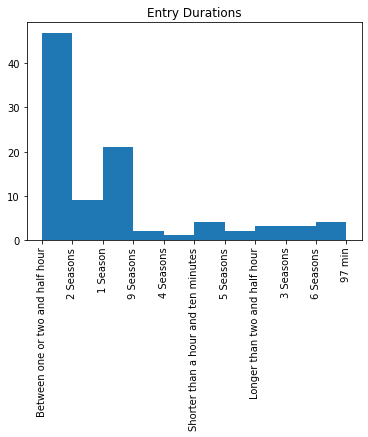

```python
plt.hist(df["duration"])
plt.title('Entry Durations')
plt.xticks(rotation = 90)
plt.show()
```

We use one hot encoding to make other values categorical.

```python
transformer = make_column_transformer(
    (OneHotEncoder(), ['type','release_year','rating','duration']),remainder='passthrough',sparse_threshold=0)

transformed = transformer.fit_transform(df)
transformed_df = pd.DataFrame(
    transformed,
    columns=transformer.get_feature_names_out()
)

transformed_df.columns = transformed_df.columns.str.replace("onehotencoder__", " ")

transformed_df.columns = transformed_df.columns.str.replace("remainder__", " ")
```

Because we have too much columns we drop ones with less than 5 occurrence so we can work with our data better.

```python
vec = CountVectorizer(stop_words='english')
X1 = vec.fit_transform(transformed_df[" title"])
count_array = X1.toarray()
X1 = pd.DataFrame(data=count_array,columns = vec.get_feature_names_out())
for (columnName, columnData) in X1.iteritems():
  if(X1[columnName].sum()<5):
    X1=X1.drop([columnName],axis=1)
transformed_df = pd.concat([transformed_df,X1], axis=1, join='inner')
transformed_df=transformed_df.drop([' title'],axis=1)
transformed_df=transformed_df.drop([' date_added'],axis=1)
transformed_df=transformed_df.drop([' show_id'],axis=1)
```

```python
X2 = vec.fit_transform(transformed_df[" description"])
count_array = X2.toarray()
X2 = pd.DataFrame(data=count_array,columns = vec.get_feature_names_out())
for (columnName, columnData) in X2.iteritems():
  if(X2[columnName].sum()<5):
    X2=X2.drop([columnName],axis=1)
transformed_df = pd.concat([transformed_df,X1], axis=1, join='inner')
transformed_df=transformed_df.drop([' description'],axis=1)
```

```python
score=transformed_df[" Score"]
transformed_df=transformed_df.drop([' Score'],axis=1)
transformed_df["score"] = score
```

```python
for (columnName, columnData) in transformed_df.iteritems():
  if(type(columnData.values[0])==int or type(columnData.values[0])==float):
    if(columnData.values[0]==1 or columnData.values[0]==0):
        if(transformed_df[columnName].value_counts()[1]<5):
          transformed_df=transformed_df.drop([columnName],axis=1)
```

```python
transformed_df.head()
```

|  | type_Movie | type_TV Show | release_year_2018 | release_year_2020 | release_year_2021 | rating_PG | rating_PG-13 | rating_TV-14 | rating_TV-MA | rating_TV-PG | rating_TV-Y | rating_TV-Y7 | duration_1 Season | duration_2 Seasons | duration_Between one or two and half hour | listed_in_ Anime Features | listed_in_ Dramas | listed_in_ International Movies | listed_in_ International TV Shows | listed_in_ TV Comedies | listed_in_ TV Dramas | listed_in_ Thrillers | listed_in_Action & Adventure | listed_in_British TV Shows | listed_in_Children & Family Movies | listed_in_Comedies | listed_in_Crime TV Shows | listed_in_Documentaries | listed_in_Dramas | … |
| --- | --- | --- | --- | --- | --- | --- | --- | --- | --- | --- | --- | --- | --- | --- | --- | --- | --- | --- | --- | --- | --- | --- | --- | --- | --- | --- | --- | --- | --- | --- |
| 0 | 1.0 | 0.0 | 0.0 | 1.0 | 0.0 | 0.0 | 1.0 | 0.0 | 0.0 | 0.0 | 0.0 | 0.0 | 0.0 | 0.0 | 1.0 | 0 | 0 | 0 | 0 | 0 | 0 | 0 | 0 | 0 | 0 | 0 | 0 | 1 | 0 | … |
| 1 | 0.0 | 1.0 | 0.0 | 0.0 | 1.0 | 0.0 | 0.0 | 0.0 | 1.0 | 0.0 | 0.0 | 0.0 | 0.0 | 1.0 | 0.0 | 0 | 0 | 0 | 0 | 0 | 1 | 0 | 0 | 0 | 0 | 0 | 0 | 0 | 0 | … |
| 2 | 0.0 | 1.0 | 0.0 | 0.0 | 1.0 | 0.0 | 0.0 | 0.0 | 1.0 | 0.0 | 0.0 | 0.0 | 1.0 | 0.0 | 0.0 | 0 | 0 | 0 | 1 | 0 | 0 | 0 | 0 | 0 | 0 | 0 | 1 | 0 | 0 | … |
| 3 | 0.0 | 1.0 | 0.0 | 0.0 | 1.0 | 0.0 | 0.0 | 0.0 | 1.0 | 0.0 | 0.0 | 0.0 | 0.0 | 1.0 | 0.0 | 0 | 0 | 0 | 0 | 1 | 0 | 0 | 0 | 0 | 0 | 0 | 0 | 0 | 0 | … |
| 4 | 0.0 | 1.0 | 0.0 | 0.0 | 1.0 | 0.0 | 0.0 | 0.0 | 1.0 | 0.0 | 0.0 | 0.0 | 1.0 | 0.0 | 0.0 | 0 | 0 | 0 | 0 | 0 | 0 | 0 | 0 | 0 | 0 | 0 | 0 | 0 | 0 | … |

```python
transformed_df.describe()
```

|  | movie | naruto | movie | naruto |
| --- | --- | --- | --- | --- |
| count | 96.000000 | 96.000000 | 96.000000 | 96.000000 |
| mean | 0.125000 | 0.083333 | 0.125000 | 0.083333 |
| std | 0.332455 | 0.277836 | 0.332455 | 0.277836 |
| min | 0.000000 | 0.000000 | 0.000000 | 0.000000 |
| 25% | 0.000000 | 0.000000 | 0.000000 | 0.000000 |
| 50% | 0.000000 | 0.000000 | 0.000000 | 0.000000 |
| 75% | 0.000000 | 0.000000 | 0.000000 | 0.000000 |
| max | 1.000000 | 1.000000 | 1.000000 | 1.000000 |

As we can see we don't have much correlation with anything.

```python
transformed_df.astype('float64').corr()
```

|  | type_Movie | type_TV Show | release_year_2018 | release_year_2020 | release_year_2021 | rating_PG | rating_PG-13 | rating_TV-14 | rating_TV-MA | rating_TV-PG | rating_TV-Y | rating_TV-Y7 | duration_1 Season | duration_2 Seasons | duration_Between one or two and half hour | listed_in_ Anime Features | listed_in_ Dramas | listed_in_ International Movies | listed_in_ International TV Shows | listed_in_ TV Comedies | listed_in_ TV Dramas | listed_in_ Thrillers | listed_in_Action & Adventure | listed_in_British TV Shows | listed_in_Children & Family Movies | listed_in_Comedies | listed_in_Crime TV Shows | listed_in_Documentaries | listed_in_Dramas | … |
| --- | --- | --- | --- | --- | --- | --- | --- | --- | --- | --- | --- | --- | --- | --- | --- | --- | --- | --- | --- | --- | --- | --- | --- | --- | --- | --- | --- | --- | --- | --- |
| type_Movie | 1.000000 | -1.000000 | 0.012834 | -0.000844 | -0.346827 | 0.222928 | 0.260324 | 0.069530 | -0.327593 | 0.124695 | -0.081941 | -0.212054 | -0.612870 | -0.372521 | 0.845593 | 0.326333 | 0.242139 | 0.540092 | -0.372521 | -0.324821 | -0.416655 | 0.242139 | 0.442913 | -0.271490 | 0.260324 | 0.242139 | -0.299050 | 0.242139 | 2.603240e-01 | … |
| type_TV Show | -1.000000 | 1.000000 | -0.012834 | 0.000844 | 0.346827 | -0.222928 | -0.260324 | -0.069530 | 0.327593 | -0.124695 | 0.081941 | 0.212054 | 0.612870 | 0.372521 | -0.845593 | -0.326333 | -0.242139 | -0.540092 | 0.372521 | 0.324821 | 0.416655 | -0.242139 | -0.442913 | 0.271490 | -0.260324 | -0.242139 | 0.299050 | -0.242139 | -2.603240e-01 | … |
| release_year_2018 | 0.012834 | -0.012834 | 1.000000 | -0.065738 | -0.249542 | 0.133150 | -0.070675 | 0.014072 | 0.033150 | -0.108736 | -0.054945 | 0.133150 | -0.010632 | -0.075392 | -0.135788 | -0.088596 | -0.065738 | -0.042360 | -0.075392 | 0.114572 | 0.062860 | -0.065738 | -0.120247 | -0.054945 | 0.098945 | -0.065738 | -0.060523 | 0.114572 | 9.894549e-02 | … |
| release_year_2020 | -0.000844 | 0.000844 | -0.065738 | 1.000000 | -0.298561 | -0.072412 | 0.060399 | -0.025145 | 0.226637 | -0.130096 | -0.065738 | -0.072412 | -0.051486 | 0.047249 | -0.034229 | -0.106000 | 0.229535 | 0.002785 | 0.047249 | 0.229535 | 0.024895 | -0.078652 | -0.045215 | 0.114572 | -0.084559 | 0.075441 | 0.093101 | 0.229535 | -8.455858e-02 | … |
| release_year_2021 | -0.346827 | 0.346827 | -0.249542 | -0.298561 | 1.000000 | -0.102404 | -0.169932 | -0.001709 | 0.265684 | -0.275117 | 0.126239 | 0.156301 | 0.194086 | 0.158894 | -0.290997 | -0.402374 | -0.057705 | -0.294523 | 0.087280 | -0.057705 | 0.075775 | -0.137990 | -0.443320 | 0.126239 | 0.207695 | -0.137990 | 0.156301 | 0.022580 | -1.888137e-02 | … |
| rating_PG | 0.222928 | -0.222928 | 0.133150 | -0.072412 | -0.102404 | 1.000000 | -0.077850 | -0.119775 | -0.182574 | -0.119775 | -0.060523 | -0.066667 | -0.136626 | -0.083045 | 0.177550 | -0.097590 | 0.093101 | -0.161515 | -0.083045 | -0.072412 | -0.092884 | 0.258613 | 0.079472 | -0.060523 | 0.233550 | -0.072412 | -0.066667 | 0.093101 | 7.784989e-02 | … |
| rating_PG-13 | 0.260324 | -0.260324 | -0.070675 | 0.060399 | -0.169932 | -0.077850 | 1.000000 | -0.139867 | -0.213201 | -0.139867 | -0.070675 | -0.077850 | -0.159545 | -0.096976 | 0.307860 | -0.113961 | 0.205357 | -0.188608 | -0.096976 | -0.084559 | -0.108465 | 0.060399 | 0.030934 | -0.070675 | -0.090909 | 0.205357 | -0.077850 | 0.205357 | -9.090909e-02 | … |
| rating_TV-14 | 0.069530 | -0.069530 | 0.014072 | -0.025145 | -0.001709 | -0.119775 | -0.139867 | 1.000000 | -0.328017 | -0.215190 | -0.108736 | -0.119775 | -0.113450 | -0.055585 | 0.091546 | 0.154705 | 0.079807 | 0.316733 | 0.131648 | -0.025145 | 0.004462 | -0.130096 | 0.030796 | 0.014072 | -0.139867 | 0.184759 | 0.105684 | 0.079807 | -4.113729e-02 | … |
| rating_TV-MA | -0.327593 | 0.327593 | 0.033150 | 0.226637 | 0.265684 | -0.182574 | -0.213201 | -0.328017 | 1.000000 | -0.328017 | -0.165748 | -0.182574 | 0.267261 | 0.151620 | -0.338896 | -0.267261 | -0.028330 | -0.098295 | 0.151620 | 0.056659 | 0.231249 | 0.056659 | -0.253917 | 0.132599 | -0.213201 | -0.198307 | 0.182574 | -0.028330 | 1.865506e-01 | … |
| rating_TV-PG | 0.124695 | -0.124695 | -0.108736 | -0.130096 | -0.275117 | -0.119775 | -0.139867 | -0.215190 | -0.328017 | 1.000000 | -0.108736 | -0.119775 | -0.113450 | -0.055585 | 0.146133 | 0.484742 | -0.130096 | 0.316733 | -0.149201 | -0.025145 | 0.004462 | -0.130096 | 0.299560 | -0.108736 | 0.057592 | 0.079807 | -0.119775 | -0.130096 | -1.398668e-01 | … |
| rating_TV-Y | -0.081941 | 0.081941 | -0.054945 | -0.065738 | 0.126239 | -0.060523 | -0.070675 | -0.108736 | -0.165748 | -0.108736 | 1.000000 | -0.060523 | -0.010632 | 0.085444 | -0.229570 | -0.088596 | -0.065738 | -0.146630 | -0.075392 | -0.065738 | -0.084324 | -0.065738 | -0.120247 | 0.156044 | 0.268566 | -0.065738 | -0.060523 | -0.065738 | -7.067535e-02 | … |
| rating_TV-Y7 | -0.212054 | 0.212054 | 0.133150 | -0.072412 | 0.156301 | -0.066667 | -0.077850 | -0.119775 | -0.182574 | -0.119775 | -0.060523 | 1.000000 | 0.175662 | 0.064591 | -0.166790 | -0.097590 | -0.072412 | -0.161515 | -0.083045 | 0.258613 | -0.092884 | -0.072412 | -0.132453 | -0.060523 | 0.077850 | -0.072412 | -0.066667 | -0.072412 | -7.784989e-02 | … |
| duration_1 Season | -0.612870 | 0.612870 | -0.010632 | -0.051486 | 0.194086 | -0.136626 | -0.159545 | -0.113450 | 0.267261 | -0.113450 | -0.010632 | 0.175662 | 1.000000 | -0.170193 | -0.518239 | -0.200000 | -0.148400 | -0.331006 | 0.348490 | 0.045428 | 0.126080 | -0.148400 | -0.271448 | 0.102772 | -0.159545 | -0.148400 | 0.279758 | -0.148400 | -1.595448e-01 | … |
| duration_2 Seasons | -0.372521 | 0.372521 | -0.075392 | 0.047249 | 0.158894 | -0.083045 | -0.096976 | -0.055585 | 0.151620 | -0.055585 | 0.085444 | 0.064591 | -0.170193 | 1.000000 | -0.315001 | -0.121566 | -0.090202 | -0.201196 | 0.019157 | 0.184699 | 0.333087 | -0.090202 | -0.164995 | -0.075392 | -0.096976 | -0.090202 | 0.064591 | -0.090202 | -9.697623e-02 | … |
| duration_Between one or two and half hour | 0.845593 | -0.845593 | -0.135788 | -0.034229 | -0.290997 | 0.177550 | 0.307860 | 0.091546 | -0.338896 | 0.146133 | -0.229570 | -0.166790 | -0.518239 | -0.315001 | 1.000000 | 0.385922 | 0.286354 | 0.453328 | -0.315001 | -0.274666 | -0.352320 | 0.286354 | 0.523790 | -0.229570 | 0.157071 | 0.126063 | -0.252875 | 0.045917 | 2.324654e-01 | … |
| listed_in_ Anime Features | 0.326333 | -0.326333 | -0.088596 | -0.106000 | -0.402374 | -0.097590 | -0.113961 | 0.154705 | -0.267261 | 0.484742 | -0.088596 | -0.097590 | -0.200000 | -0.121566 | 0.385922 | 1.000000 | -0.106000 | 0.604218 | -0.121566 | -0.106000 | -0.135968 | -0.106000 | 0.736788 | -0.088596 | -0.113961 | -0.106000 | -0.097590 | -0.106000 | -1.139606e-01 | … |
| listed_in_ Dramas | 0.242139 | -0.242139 | -0.065738 | 0.229535 | -0.057705 | 0.093101 | 0.205357 | 0.079807 | -0.028330 | -0.130096 | -0.065738 | -0.072412 | -0.148400 | -0.090202 | 0.286354 | -0.106000 | 1.000000 | 0.091893 | -0.090202 | -0.078652 | -0.100888 | -0.078652 | 0.250740 | -0.065738 | -0.084559 | 0.383628 | -0.072412 | -0.078652 | -8.455858e-02 | … |
| listed_in_ International Movies | 0.540092 | -0.540092 | -0.042360 | 0.002785 | -0.294523 | -0.161515 | -0.188608 | 0.316733 | -0.098295 | 0.316733 | -0.146630 | -0.161515 | -0.331006 | -0.201196 | 0.453328 | 0.604218 | 0.091893 | 1.000000 | -0.201196 | -0.175433 | -0.225032 | -0.086324 | 0.420732 | -0.146630 | -0.188608 | 0.270111 | -0.161515 | 0.091893 | 3.143473e-01 | … |
| listed_in_ International TV Shows | -0.372521 | 0.372521 | -0.075392 | 0.047249 | 0.087280 | -0.083045 | -0.096976 | 0.131648 | 0.151620 | -0.149201 | -0.075392 | -0.083045 | 0.348490 | 0.019157 | -0.315001 | -0.121566 | -0.090202 | -0.201196 | 1.000000 | 0.047249 | -0.115704 | -0.090202 | -0.164995 | 0.246281 | -0.096976 | -0.090202 | 0.507500 | -0.090202 | -9.697623e-02 | … |
| listed_in_ TV Comedies | -0.324821 | 0.324821 | 0.114572 | 0.229535 | -0.057705 | -0.072412 | -0.084559 | -0.025145 | 0.056659 | -0.025145 | -0.065738 | 0.258613 | 0.045428 | 0.184699 | -0.274666 | -0.106000 | -0.078652 | -0.175433 | 0.047249 | 1.000000 | 0.024895 | -0.078652 | -0.143867 | 0.114572 | -0.084559 | -0.078652 | 0.093101 | -0.078652 | -8.455858e-02 | … |
| listed_in_ TV Dramas | -0.416655 | 0.416655 | 0.062860 | 0.024895 | 0.075775 | -0.092884 | -0.108465 | 0.004462 | 0.231249 | 0.004462 | -0.084324 | -0.092884 | 0.126080 | 0.333087 | -0.352320 | -0.135968 | -0.100888 | -0.225032 | -0.115704 | 0.024895 | 1.000000 | -0.100888 | -0.184542 | -0.084324 | -0.108465 | -0.100888 | 0.177324 | -0.100888 | -1.084652e-01 | … |
| listed_in_ Thrillers | 0.242139 | -0.242139 | -0.065738 | -0.078652 | -0.137990 | 0.258613 | 0.060399 | -0.130096 | 0.056659 | -0.130096 | -0.065738 | -0.072412 | -0.148400 | -0.090202 | 0.286354 | -0.106000 | -0.078652 | -0.086324 | -0.090202 | -0.078652 | -0.100888 | 1.000000 | 0.053436 | -0.065738 | -0.084559 | -0.078652 | -0.072412 | -0.078652 | 3.503141e-01 | … |
| listed_in_Action & Adventure | 0.442913 | -0.442913 | -0.120247 | -0.045215 | -0.443320 | 0.079472 | 0.030934 | 0.030796 | -0.253917 | 0.299560 | -0.120247 | -0.132453 | -0.271448 | -0.164995 | 0.523790 | 0.736788 | 0.250740 | 0.420732 | -0.164995 | -0.143867 | -0.184542 | 0.053436 | 1.000000 | -0.120247 | -0.154672 | -0.143867 | -0.132453 | -0.143867 | -1.546721e-01 | … |
| listed_in_British TV Shows | -0.271490 | 0.271490 | -0.054945 | 0.114572 | 0.126239 | -0.060523 | -0.070675 | 0.014072 | 0.132599 | -0.108736 | 0.156044 | -0.060523 | 0.102772 | -0.075392 | -0.229570 | -0.088596 | -0.065738 | -0.146630 | 0.246281 | 0.114572 | -0.084324 | -0.065738 | -0.120247 | 1.000000 | -0.070675 | -0.065738 | -0.060523 | -0.065738 | -7.067535e-02 | … |
| listed_in_Children & Family Movies | 0.260324 | -0.260324 | 0.098945 | -0.084559 | 0.207695 | 0.233550 | -0.090909 | -0.139867 | -0.213201 | 0.057592 | 0.268566 | 0.077850 | -0.159545 | -0.096976 | 0.157071 | -0.113961 | -0.084559 | -0.188608 | -0.096976 | -0.084559 | -0.108465 | -0.084559 | -0.154672 | -0.070675 | 1.000000 | -0.084559 | -0.077850 | -0.084559 | -9.090909e-02 | … |
| listed_in_Comedies | 0.242139 | -0.242139 | -0.065738 | 0.075441 | -0.137990 | -0.072412 | 0.205357 | 0.184759 | -0.198307 | 0.079807 | -0.065738 | -0.072412 | -0.148400 | -0.090202 | 0.126063 | -0.106000 | 0.383628 | 0.270111 | -0.090202 | -0.078652 | -0.100888 | -0.078652 | -0.143867 | -0.065738 | -0.084559 | 1.000000 | -0.072412 | -0.078652 | -8.455858e-02 | … |
| listed_in_Crime TV Shows | -0.299050 | 0.299050 | -0.060523 | 0.093101 | 0.156301 | -0.066667 | -0.077850 | 0.105684 | 0.182574 | -0.119775 | -0.060523 | -0.066667 | 0.279758 | 0.064591 | -0.252875 | -0.097590 | -0.072412 | -0.161515 | 0.507500 | 0.093101 | 0.177324 | -0.072412 | -0.132453 | -0.060523 | -0.077850 | -0.072412 | 1.000000 | -0.072412 | -7.784989e-02 | … |
| listed_in_Documentaries | 0.242139 | -0.242139 | 0.114572 | 0.229535 | 0.022580 | 0.093101 | 0.205357 | 0.079807 | -0.028330 | -0.130096 | -0.065738 | -0.072412 | -0.148400 | -0.090202 | 0.045917 | -0.106000 | -0.078652 | 0.091893 | -0.090202 | -0.078652 | -0.100888 | -0.078652 | -0.143867 | -0.065738 | -0.084559 | -0.078652 | -0.072412 | 1.000000 | -8.455858e-02 | … |
| listed_in_Dramas | 0.260324 | -0.260324 | 0.098945 | -0.084559 | -0.018881 | 0.077850 | -0.090909 | -0.041137 | 0.186551 | -0.139867 | -0.070675 | -0.077850 | -0.159545 | -0.096976 | 0.232465 | -0.113961 | -0.084559 | 0.314347 | -0.096976 | -0.084559 | -0.108465 | 0.350314 | -0.154672 | -0.070675 | -0.090909 | -0.084559 | -0.077850 | -0.084559 | 1.000000e+00 | … |
| listed_in_International TV Shows | -0.416655 | 0.416655 | 0.062860 | 0.024895 | 0.075775 | -0.092884 | -0.108465 | -0.081208 | 0.300623 | 0.004462 | -0.084324 | -0.092884 | 0.284297 | 0.333087 | -0.352320 | -0.135968 | -0.100888 | -0.225032 | -0.115704 | 0.150677 | 0.589305 | -0.100888 | -0.184542 | -0.084324 | -0.108465 | -0.100888 | -0.092884 | -0.100888 | -1.084652e-01 | … |
| listed_in_Kids' TV | -0.324821 | 0.324821 | 0.114572 | -0.078652 | 0.022580 | -0.072412 | -0.084559 | -0.130096 | -0.198307 | -0.025145 | 0.294883 | 0.589638 | 0.045428 | 0.184699 | -0.274666 | -0.106000 | -0.078652 | -0.175433 | -0.090202 | 0.383628 | -0.100888 | -0.078652 | -0.143867 | -0.065738 | -0.084559 | -0.078652 | -0.072412 | -0.078652 | -8.455858e-02 | … |
| country_ United States | 0.107609 | -0.107609 | 0.156044 | -0.065738 | -0.155597 | 0.133150 | 0.098945 | -0.108736 | 0.033150 | -0.108736 | -0.054945 | -0.060523 | -0.010632 | -0.075392 | 0.145557 | -0.088596 | 0.114572 | -0.146630 | -0.075392 | -0.065738 | 0.062860 | 0.114572 | 0.110627 | -0.054945 | 0.098945 | -0.065738 | -0.060523 | -0.065738 | -7.067535e-02 | … |
| country_India | -0.055715 | 0.055715 | -0.088596 | 0.015143 | -0.086787 | -0.097590 | -0.113961 | 0.154705 | -0.133631 | 0.154705 | -0.088596 | 0.032530 | 0.104762 | -0.013507 | -0.118140 | -0.142857 | 0.136285 | 0.183892 | -0.013507 | 0.015143 | 0.061804 | -0.106000 | -0.193892 | 0.053158 | -0.113961 | 0.499713 | -0.097590 | -0.106000 | -7.907603e-18 | … |
| country_Japan | 0.280154 | -0.280154 | -0.092768 | -0.110991 | -0.421319 | -0.102185 | -0.119326 | 0.215155 | -0.279845 | 0.454400 | -0.092768 | -0.102185 | -0.135776 | -0.127290 | 0.343194 | 0.955033 | -0.110991 | 0.564957 | -0.022847 | -0.110991 | -0.142370 | -0.110991 | 0.696518 | -0.092768 | -0.119326 | -0.110991 | -0.102185 | -0.110991 | -1.193263e-01 | … |
| country_United Kingdom | -0.273023 | 0.273023 | 0.098945 | 0.060399 | 0.132170 | 0.077850 | -0.090909 | -0.041137 | 0.106600 | -0.139867 | 0.268566 | -0.077850 | 0.113961 | -0.096976 | -0.219900 | -0.113961 | -0.084559 | -0.188608 | 0.290929 | 0.060399 | -0.108465 | -0.084559 | -0.154672 | 0.607808 | 0.045455 | -0.084559 | 0.077850 | -0.084559 | -9.090909e-02 | … |
| country_United States | 0.059810 | -0.059810 | -0.084732 | -0.134479 | 0.210198 | 0.244444 | 0.311400 | -0.190230 | -0.136931 | -0.133866 | 0.012105 | 0.066667 | -0.045542 | -0.101500 | 0.016141 | -0.292770 | -0.051723 | -0.436688 | -0.175318 | 0.031034 | -0.143548 | 0.196546 | -0.185435 | -0.181568 | 0.155700 | -0.051723 | -0.022222 | 0.113790 | -1.620576e-18 | … |
| cast_ Chie Nakamura | 0.260324 | -0.260324 | -0.070675 | -0.084559 | -0.320983 | -0.077850 | -0.090909 | 0.057592 | -0.213201 | 0.452510 | -0.070675 | -0.077850 | -0.159545 | -0.096976 | 0.307860 | 0.797724 | -0.084559 | 0.481999 | -0.096976 | -0.084559 | -0.108465 | -0.084559 | 0.587754 | -0.070675 | -0.090909 | -0.084559 | -0.077850 | -0.084559 | -9.090909e-02 | … |
| cast_ Houko Kuwashima | 0.202383 | -0.202383 | -0.054945 | -0.065738 | -0.249542 | -0.060523 | -0.070675 | 0.136880 | -0.165748 | 0.259688 | -0.054945 | -0.060523 | -0.124035 | -0.075392 | 0.239339 | 0.620174 | -0.065738 | 0.374720 | -0.075392 | -0.065738 | -0.084324 | -0.065738 | 0.456937 | -0.054945 | -0.070675 | -0.065738 | -0.060523 | -0.065738 | -7.067535e-02 | … |
| cast_ Kazuhiko Inoue | 0.222928 | -0.222928 | -0.060523 | -0.072412 | -0.274874 | -0.066667 | -0.077850 | -0.007046 | -0.182574 | 0.443871 | -0.060523 | -0.066667 | -0.136626 | -0.083045 | 0.263635 | 0.683130 | -0.072412 | 0.412759 | -0.083045 | -0.072412 | -0.092884 | -0.072412 | 0.503322 | -0.060523 | -0.077850 | -0.072412 | -0.066667 | -0.072412 | -7.784989e-02 | … |
| cast_ Showtaro Morikubo | 0.107609 | -0.107609 | -0.054945 | -0.065738 | -0.249542 | -0.060523 | -0.070675 | 0.014072 | -0.165748 | 0.382497 | -0.054945 | -0.060523 | -0.010632 | -0.075392 | 0.145557 | 0.478420 | -0.065738 | 0.270450 | 0.085444 | -0.065738 | -0.084324 | -0.065738 | 0.341500 | -0.054945 | -0.070675 | -0.065738 | -0.060523 | -0.065738 | -7.067535e-02 | … |
| cast_Junko Takeuchi | 0.260324 | -0.260324 | -0.070675 | -0.084559 | -0.320983 | -0.077850 | -0.090909 | 0.057592 | -0.213201 | 0.452510 | -0.070675 | -0.077850 | -0.159545 | -0.096976 | 0.307860 | 0.797724 | -0.084559 | 0.481999 | -0.096976 | -0.084559 | -0.108465 | -0.084559 | 0.587754 | -0.070675 | -0.090909 | -0.084559 | -0.077850 | -0.084559 | -9.090909e-02 | … |
| director_Tv Show | -0.799859 | 0.799859 | -0.061618 | -0.022313 | 0.291567 | -0.178311 | -0.208223 | -0.145286 | 0.220534 | -0.028571 | 0.138902 | 0.189815 | 0.389005 | 0.389305 | -0.676356 | -0.261021 | -0.193677 | -0.431998 | 0.160021 | 0.234733 | 0.450970 | -0.193677 | -0.354268 | 0.239162 | -0.208223 | -0.193677 | 0.097784 | -0.193677 | -2.082226e-01 | … |
| movie | 0.326333 | -0.326333 | -0.088596 | -0.106000 | -0.402374 | -0.097590 | -0.113961 | 0.154705 | -0.267261 | 0.484742 | -0.088596 | -0.097590 | -0.200000 | -0.121566 | 0.385922 | 1.000000 | -0.106000 | 0.604218 | -0.121566 | -0.106000 | -0.135968 | -0.106000 | 0.736788 | -0.088596 | -0.113961 | -0.106000 | -0.097590 | -0.106000 | -1.139606e-01 | … |
| naruto | 0.260324 | -0.260324 | -0.070675 | -0.084559 | -0.320983 | -0.077850 | -0.090909 | 0.057592 | -0.213201 | 0.452510 | -0.070675 | -0.077850 | -0.159545 | -0.096976 | 0.307860 | 0.797724 | -0.084559 | 0.481999 | -0.096976 | -0.084559 | -0.108465 | -0.084559 | 0.587754 | -0.070675 | -0.090909 | -0.084559 | -0.077850 | -0.084559 | -9.090909e-02 | … |
| movie | 0.326333 | -0.326333 | -0.088596 | -0.106000 | -0.402374 | -0.097590 | -0.113961 | 0.154705 | -0.267261 | 0.484742 | -0.088596 | -0.097590 | -0.200000 | -0.121566 | 0.385922 | 1.000000 | -0.106000 | 0.604218 | -0.121566 | -0.106000 | -0.135968 | -0.106000 | 0.736788 | -0.088596 | -0.113961 | -0.106000 | -0.097590 | -0.106000 | -1.139606e-01 | … |
| naruto | 0.260324 | -0.260324 | -0.070675 | -0.084559 | -0.320983 | -0.077850 | -0.090909 | 0.057592 | -0.213201 | 0.452510 | -0.070675 | -0.077850 | -0.159545 | -0.096976 | 0.307860 | 0.797724 | -0.084559 | 0.481999 | -0.096976 | -0.084559 | -0.108465 | -0.084559 | 0.587754 | -0.070675 | -0.090909 | -0.084559 | -0.077850 | -0.084559 | -9.090909e-02 | … |
| score | -0.329701 | 0.329701 | -0.050011 | 0.097299 | -0.070669 | -0.182609 | -0.189152 | 0.088913 | -0.035308 | 0.122209 | 0.162460 | -0.077591 | 0.082561 | 0.233507 | -0.370591 | 0.086816 | -0.042375 | -0.038555 | 0.186786 | 0.243957 | 0.248187 | -0.360134 | -0.049088 | 0.248265 | -0.215431 | -0.087769 | 0.042429 | 0.114759 | -1.563038e-01 | … |

```python
cl=[]
for i in range(len(transformed_df['score'])):
 try:
  if ( transformed_df['score'][i]>6.5 ):
   cl.append('Higher than median')
  elif(transformed_df['score'][i]<=6.5):
   cl.append('Lower than median')
 except(KeyError):
  continue
transformed_df['Class']=cl
transformed_df
```

|  | type_Movie | type_TV Show | release_year_2018 | release_year_2020 | release_year_2021 | rating_PG | rating_PG-13 | rating_TV-14 | rating_TV-MA | rating_TV-PG | rating_TV-Y | rating_TV-Y7 | duration_1 Season | duration_2 Seasons | duration_Between one or two and half hour | listed_in_ Anime Features | listed_in_ Dramas | listed_in_ International Movies | listed_in_ International TV Shows | listed_in_ TV Comedies | listed_in_ TV Dramas | listed_in_ Thrillers | listed_in_Action & Adventure | listed_in_British TV Shows | listed_in_Children & Family Movies | listed_in_Comedies | listed_in_Crime TV Shows | listed_in_Documentaries | listed_in_Dramas | … |
| --- | --- | --- | --- | --- | --- | --- | --- | --- | --- | --- | --- | --- | --- | --- | --- | --- | --- | --- | --- | --- | --- | --- | --- | --- | --- | --- | --- | --- | --- | --- |
| 0 | 1.0 | 0.0 | 0.0 | 1.0 | 0.0 | 0.0 | 1.0 | 0.0 | 0.0 | 0.0 | 0.0 | 0.0 | 0.0 | 0.0 | 1.0 | 0 | 0 | 0 | 0 | 0 | 0 | 0 | 0 | 0 | 0 | 0 | 0 | 1 | 0 | … |
| 1 | 0.0 | 1.0 | 0.0 | 0.0 | 1.0 | 0.0 | 0.0 | 0.0 | 1.0 | 0.0 | 0.0 | 0.0 | 0.0 | 1.0 | 0.0 | 0 | 0 | 0 | 0 | 0 | 1 | 0 | 0 | 0 | 0 | 0 | 0 | 0 | 0 | … |
| 2 | 0.0 | 1.0 | 0.0 | 0.0 | 1.0 | 0.0 | 0.0 | 0.0 | 1.0 | 0.0 | 0.0 | 0.0 | 1.0 | 0.0 | 0.0 | 0 | 0 | 0 | 1 | 0 | 0 | 0 | 0 | 0 | 0 | 0 | 1 | 0 | 0 | … |
| 3 | 0.0 | 1.0 | 0.0 | 0.0 | 1.0 | 0.0 | 0.0 | 0.0 | 1.0 | 0.0 | 0.0 | 0.0 | 0.0 | 1.0 | 0.0 | 0 | 0 | 0 | 0 | 1 | 0 | 0 | 0 | 0 | 0 | 0 | 0 | 0 | 0 | … |
| 4 | 0.0 | 1.0 | 0.0 | 0.0 | 1.0 | 0.0 | 0.0 | 0.0 | 1.0 | 0.0 | 0.0 | 0.0 | 1.0 | 0.0 | 0.0 | 0 | 0 | 0 | 0 | 0 | 0 | 0 | 0 | 0 | 0 | 0 | 0 | 0 | 0 | … |
| 5 | 1.0 | 0.0 | 0.0 | 0.0 | 1.0 | 1.0 | 0.0 | 0.0 | 0.0 | 0.0 | 0.0 | 0.0 | 0.0 | 0.0 | 1.0 | 0 | 0 | 0 | 0 | 0 | 0 | 0 | 0 | 0 | 1 | 0 | 0 | 0 | 0 | … |
| 6 | 1.0 | 0.0 | 0.0 | 0.0 | 0.0 | 0.0 | 0.0 | 0.0 | 1.0 | 0.0 | 0.0 | 0.0 | 0.0 | 0.0 | 1.0 | 0 | 0 | 1 | 0 | 0 | 0 | 0 | 0 | 0 | 0 | 0 | 0 | 0 | 1 | … |
| 7 | 0.0 | 1.0 | 0.0 | 0.0 | 1.0 | 0.0 | 0.0 | 1.0 | 0.0 | 0.0 | 0.0 | 0.0 | 0.0 | 0.0 | 0.0 | 0 | 0 | 0 | 0 | 0 | 0 | 0 | 0 | 1 | 0 | 0 | 0 | 0 | 0 | … |
| 8 | 1.0 | 0.0 | 0.0 | 0.0 | 1.0 | 0.0 | 1.0 | 0.0 | 0.0 | 0.0 | 0.0 | 0.0 | 0.0 | 0.0 | 1.0 | 0 | 1 | 0 | 0 | 0 | 0 | 0 | 0 | 0 | 0 | 1 | 0 | 0 | 0 | … |
| 9 | 0.0 | 1.0 | 0.0 | 0.0 | 1.0 | 0.0 | 0.0 | 0.0 | 1.0 | 0.0 | 0.0 | 0.0 | 1.0 | 0.0 | 0.0 | 0 | 0 | 0 | 1 | 0 | 0 | 0 | 0 | 0 | 0 | 0 | 1 | 0 | 0 | … |
| 10 | 0.0 | 1.0 | 0.0 | 0.0 | 1.0 | 0.0 | 0.0 | 0.0 | 1.0 | 0.0 | 0.0 | 0.0 | 1.0 | 0.0 | 0.0 | 0 | 0 | 0 | 1 | 0 | 0 | 0 | 0 | 0 | 0 | 0 | 1 | 0 | 0 | … |
| 11 | 1.0 | 0.0 | 0.0 | 0.0 | 1.0 | 0.0 | 0.0 | 0.0 | 1.0 | 0.0 | 0.0 | 0.0 | 0.0 | 0.0 | 1.0 | 0 | 0 | 1 | 0 | 0 | 0 | 0 | 0 | 0 | 0 | 0 | 0 | 0 | 1 | … |
| 12 | 1.0 | 0.0 | 0.0 | 0.0 | 1.0 | 0.0 | 0.0 | 0.0 | 0.0 | 1.0 | 0.0 | 0.0 | 0.0 | 0.0 | 1.0 | 0 | 0 | 0 | 0 | 0 | 0 | 0 | 0 | 0 | 1 | 0 | 0 | 0 | 0 | … |
| 13 | 0.0 | 1.0 | 0.0 | 0.0 | 1.0 | 0.0 | 0.0 | 0.0 | 1.0 | 0.0 | 0.0 | 0.0 | 1.0 | 0.0 | 0.0 | 0 | 0 | 0 | 0 | 0 | 0 | 0 | 0 | 1 | 0 | 0 | 0 | 0 | 0 | … |
| 14 | 0.0 | 1.0 | 0.0 | 0.0 | 1.0 | 0.0 | 0.0 | 0.0 | 1.0 | 0.0 | 0.0 | 0.0 | 0.0 | 0.0 | 0.0 | 0 | 0 | 0 | 0 | 0 | 1 | 0 | 0 | 0 | 0 | 0 | 0 | 0 | 0 | … |
| 15 | 1.0 | 0.0 | 0.0 | 1.0 | 0.0 | 0.0 | 0.0 | 0.0 | 1.0 | 0.0 | 0.0 | 0.0 | 0.0 | 0.0 | 0.0 | 0 | 0 | 1 | 0 | 0 | 0 | 0 | 0 | 0 | 0 | 0 | 0 | 1 | 0 | … |
| 16 | 0.0 | 1.0 | 0.0 | 1.0 | 0.0 | 0.0 | 0.0 | 0.0 | 1.0 | 0.0 | 0.0 | 0.0 | 0.0 | 1.0 | 0.0 | 0 | 0 | 0 | 0 | 0 | 1 | 0 | 0 | 0 | 0 | 0 | 1 | 0 | 0 | … |
| 17 | 1.0 | 0.0 | 0.0 | 0.0 | 1.0 | 0.0 | 0.0 | 1.0 | 0.0 | 0.0 | 0.0 | 0.0 | 0.0 | 0.0 | 1.0 | 0 | 0 | 0 | 0 | 0 | 0 | 0 | 0 | 0 | 0 | 0 | 0 | 0 | 0 | … |
| 18 | 0.0 | 1.0 | 0.0 | 0.0 | 1.0 | 0.0 | 0.0 | 0.0 | 1.0 | 0.0 | 0.0 | 0.0 | 1.0 | 0.0 | 0.0 | 0 | 0 | 0 | 0 | 0 | 0 | 0 | 0 | 0 | 0 | 0 | 0 | 0 | 0 | … |
| 19 | 0.0 | 1.0 | 0.0 | 0.0 | 1.0 | 0.0 | 0.0 | 1.0 | 0.0 | 0.0 | 0.0 | 0.0 | 1.0 | 0.0 | 0.0 | 0 | 0 | 0 | 1 | 0 | 0 | 0 | 0 | 0 | 0 | 0 | 1 | 0 | 0 | … |
| 20 | 0.0 | 1.0 | 1.0 | 0.0 | 0.0 | 0.0 | 0.0 | 1.0 | 0.0 | 0.0 | 0.0 | 0.0 | 0.0 | 0.0 | 0.0 | 0 | 0 | 0 | 0 | 0 | 1 | 0 | 0 | 0 | 0 | 0 | 0 | 0 | 0 | … |
| 21 | 1.0 | 0.0 | 0.0 | 0.0 | 0.0 | 0.0 | 0.0 | 0.0 | 0.0 | 1.0 | 0.0 | 0.0 | 0.0 | 0.0 | 0.0 | 0 | 0 | 1 | 0 | 0 | 0 | 0 | 0 | 0 | 0 | 1 | 0 | 0 | 0 | … |
| 22 | 1.0 | 0.0 | 0.0 | 0.0 | 1.0 | 0.0 | 0.0 | 0.0 | 0.0 | 0.0 | 1.0 | 0.0 | 0.0 | 0.0 | 0.0 | 0 | 0 | 0 | 0 | 0 | 0 | 0 | 0 | 0 | 1 | 0 | 0 | 0 | 0 | … |
| 23 | 1.0 | 0.0 | 0.0 | 0.0 | 0.0 | 0.0 | 0.0 | 1.0 | 0.0 | 0.0 | 0.0 | 0.0 | 0.0 | 0.0 | 0.0 | 0 | 0 | 1 | 0 | 0 | 0 | 0 | 0 | 0 | 0 | 1 | 0 | 0 | 0 | … |
| 24 | 0.0 | 1.0 | 0.0 | 0.0 | 1.0 | 0.0 | 0.0 | 1.0 | 0.0 | 0.0 | 0.0 | 0.0 | 0.0 | 1.0 | 0.0 | 0 | 0 | 0 | 1 | 0 | 0 | 0 | 0 | 0 | 0 | 0 | 0 | 0 | 0 | … |
| 25 | 1.0 | 0.0 | 0.0 | 0.0 | 0.0 | 0.0 | 0.0 | 0.0 | 0.0 | 1.0 | 0.0 | 0.0 | 0.0 | 0.0 | 1.0 | 0 | 0 | 1 | 0 | 0 | 0 | 0 | 0 | 0 | 0 | 1 | 0 | 0 | 0 | … |
| 26 | 1.0 | 0.0 | 0.0 | 0.0 | 0.0 | 0.0 | 1.0 | 0.0 | 0.0 | 0.0 | 0.0 | 0.0 | 0.0 | 0.0 | 1.0 | 0 | 0 | 0 | 0 | 0 | 0 | 0 | 0 | 0 | 0 | 1 | 0 | 0 | 0 | … |
| 27 | 1.0 | 0.0 | 0.0 | 0.0 | 0.0 | 0.0 | 1.0 | 0.0 | 0.0 | 0.0 | 0.0 | 0.0 | 0.0 | 0.0 | 1.0 | 0 | 0 | 0 | 0 | 0 | 0 | 0 | 0 | 0 | 0 | 0 | 0 | 0 | 0 | … |
| 28 | 1.0 | 0.0 | 0.0 | 0.0 | 0.0 | 0.0 | 1.0 | 0.0 | 0.0 | 0.0 | 0.0 | 0.0 | 0.0 | 0.0 | 1.0 | 0 | 0 | 0 | 0 | 0 | 0 | 0 | 0 | 0 | 0 | 0 | 0 | 0 | 0 | … |
| 29 | 1.0 | 0.0 | 0.0 | 0.0 | 1.0 | 0.0 | 0.0 | 1.0 | 0.0 | 0.0 | 0.0 | 0.0 | 0.0 | 0.0 | 1.0 | 0 | 0 | 1 | 0 | 0 | 0 | 0 | 0 | 0 | 0 | 0 | 0 | 0 | 1 | … |

[output cut: 66 more lines]

We use label encoder and train test split to split and prepare our data.

```python
le = preprocessing.LabelEncoder()
encoded=le.fit_transform(transformed_df['Class'])
transformed_df=transformed_df.drop(['Class'],axis=1)
X_train, X_test, y_train, y_test = train_test_split(transformed_df,encoded,test_size=0.3,random_state=25)
```

```python
knn = KNeighborsClassifier()
k_range = list(range(1, 31))
param_grid = dict(n_neighbors=k_range)
grid = GridSearchCV(knn, param_grid, cv=10, scoring='accuracy', return_train_score=False,verbose=1)
grid_search=grid.fit(X_train, y_train)
```

```
Fitting 10 folds for each of 30 candidates, totalling 300 fits
```

As seen our accuracy for classification is high.

```python
y_test_hat=grid_search.predict(X_test)

test_accuracy=accuracy_score(y_test,y_test_hat)*100

print("Accuracy for our testing dataset with tuning is : {:.2f}%".format(test_accuracy) )
```

```
Accuracy for our testing dataset with tuning is : 79.31%
```

```
<sklearn.metrics._plot.confusion_matrix.ConfusionMatrixDisplay at 0x7f1b9d5bf4c0>
```

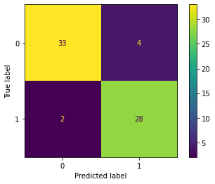

```python
plot_confusion_matrix(grid,X_train, y_train,values_format='d' )
```

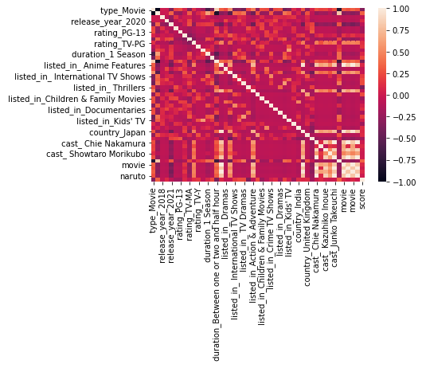

```python
sb.heatmap(transformed_df.astype('float64').corr())
score = transformed_df['score']
transformed_df=transformed_df.drop(['score'],axis=1)
```

```python
score=score.astype(int)
```

```python
X_train, X_test, y_train, y_test = train_test_split(transformed_df, score, random_state = 25,test_size=0.30)
X_train.head()
```

|  | type_Movie | type_TV Show | release_year_2018 | release_year_2020 | release_year_2021 | rating_PG | rating_PG-13 | rating_TV-14 | rating_TV-MA | rating_TV-PG | rating_TV-Y | rating_TV-Y7 | duration_1 Season | duration_2 Seasons | duration_Between one or two and half hour | listed_in_ Anime Features | listed_in_ Dramas | listed_in_ International Movies | listed_in_ International TV Shows | listed_in_ TV Comedies | listed_in_ TV Dramas | listed_in_ Thrillers | listed_in_Action & Adventure | listed_in_British TV Shows | listed_in_Children & Family Movies | listed_in_Comedies | listed_in_Crime TV Shows | listed_in_Documentaries | listed_in_Dramas | … |
| --- | --- | --- | --- | --- | --- | --- | --- | --- | --- | --- | --- | --- | --- | --- | --- | --- | --- | --- | --- | --- | --- | --- | --- | --- | --- | --- | --- | --- | --- | --- |
| 92 | 1.0 | 0.0 | 1.0 | 0.0 | 0.0 | 0.0 | 0.0 | 0.0 | 1.0 | 0.0 | 0.0 | 0.0 | 0.0 | 0.0 | 0.0 | 0 | 0 | 0 | 0 | 0 | 0 | 0 | 0 | 0 | 0 | 0 | 0 | 1 | 0 | … |
| 41 | 1.0 | 0.0 | 0.0 | 0.0 | 0.0 | 1.0 | 0.0 | 0.0 | 0.0 | 0.0 | 0.0 | 0.0 | 0.0 | 0.0 | 1.0 | 0 | 0 | 0 | 0 | 0 | 0 | 1 | 1 | 0 | 0 | 0 | 0 | 0 | 0 | … |
| 53 | 0.0 | 1.0 | 0.0 | 0.0 | 1.0 | 0.0 | 0.0 | 0.0 | 0.0 | 1.0 | 0.0 | 0.0 | 0.0 | 0.0 | 0.0 | 0 | 0 | 0 | 0 | 0 | 0 | 0 | 0 | 0 | 0 | 0 | 0 | 0 | 0 | … |
| 7 | 0.0 | 1.0 | 0.0 | 0.0 | 1.0 | 0.0 | 0.0 | 1.0 | 0.0 | 0.0 | 0.0 | 0.0 | 0.0 | 0.0 | 0.0 | 0 | 0 | 0 | 0 | 0 | 0 | 0 | 0 | 1 | 0 | 0 | 0 | 0 | 0 | … |
| 79 | 0.0 | 1.0 | 0.0 | 0.0 | 1.0 | 0.0 | 0.0 | 1.0 | 0.0 | 0.0 | 0.0 | 0.0 | 0.0 | 0.0 | 0.0 | 0 | 0 | 0 | 0 | 1 | 1 | 0 | 0 | 0 | 0 | 0 | 1 | 0 | 0 | … |

```python
print(X_test.head())
print()
print()
print(y_train.head())
```

```
    type_Movie  type_TV Show  release_year_2018  release_year_2020  release_year_2021  rating_PG  rating_PG-13  rating_TV-14  rating_TV-MA  rating_TV-PG  rating_TV-Y  rating_TV-Y7  duration_1 Season  duration_2 Seasons  duration_Between one or two and half hour  listed_in_ Anime Features  listed_in_…
52         1.0           0.0                0.0                0.0                0.0        0.0           0.0           0.0           0.0           1.0          0.0           0.0                0.0                 0.0                                        1.0                          1            …
73         1.0           0.0                0.0                0.0                1.0        0.0           0.0           0.0           0.0           0.0          0.0           0.0                0.0                 0.0                                        1.0                          0            …
91         0.0           1.0                0.0                0.0                1.0        0.0           0.0           0.0           1.0           0.0          0.0           0.0                0.0                 0.0                                        0.0                          0            …
6          1.0           0.0                0.0                0.0                0.0        0.0           0.0           0.0           1.0           0.0          0.0           0.0                0.0                 0.0                                        1.0                          0            …
54         1.0           0.0                0.0                0.0                0.0        0.0           0.0           1.0           0.0           0.0          0.0           0.0                0.0                 0.0                                        1.0                          1            …


92    7
41    3
53    7
7     8
79    8
Name: score, dtype: int64
```

We try to make a regression prediction too.

```python
scaler = MinMaxScaler(feature_range=(0, 1))
x_train_scaled = scaler.fit_transform(X_train)
x_train = pd.DataFrame(x_train_scaled)

x_test_scaled = scaler.fit_transform(X_test)
x_test = pd.DataFrame(x_test_scaled)
```

```python
knn = KNeighborsRegressor()
grid_params = { 'n_neighbors' : [5,7,9,11,13,15],
               'weights' : ['uniform','distance'],
               'metric' : ['minkowski','euclidean','manhattan']}
gs = GridSearchCV(knn, grid_params, verbose = 1, cv=3, n_jobs = -1)
g_res = gs.fit(X_train, y_train)
```

```
Fitting 3 folds for each of 36 candidates, totalling 108 fits
```

```python
g_res.best_score_
```

```
0.02823997430689018
```

```python
g_res.best_params_
```

```
{'metric': 'minkowski', 'n_neighbors': 15, 'weights': 'distance'}
```

As seen our data in current state can not make accurate predictions.

```python
print(g_res.score(X_test, y_test))
scores = cross_val_score(knn, transformed_df, score, cv =5)
print()
print()
print('Model accuracy: ',np.mean(scores))
```

```
0.11317334204763707


Model accuracy:  0.09678274964941644
```

# Results

As seen from our results we can accurately predict if something is better than avarage but we can not predict precise scores. This means we need a different dataset or columns. We can use this as it is for some predictions and we can select what is worth our time.

# References

1. https://www.kaggle.com/datasets/shivamb/netflix-shows?resource=download
2. Dynamic k determination in k-NN classifier: A literature review
3. Netflix Movie Rating Prediction using Enriched Movie Metadata